# Overview

Dataset info

[output not shown]

Variables types

| Numeric | 5 |
| --- | --- |
| Categorical | 25 |
| Boolean | 0 |
| Date | 0 |
| URL | 0 |
| Text (Unique) | 1 |
| Rejected | 5 |
| Unsupported | 0 |

Warnings

[output not shown]

# Variables

index  
Numeric

| Distinct count | 102789 |
| --- | --- |
| Unique (%) | 5.3% |
| Missing (%) | 0.0% |
| Missing (n) | 0 |
| Infinite (%) | 0.0% |
| Infinite (n) | 0 |

| Mean | 51128 |
| --- | --- |
| Minimum | 0 |
| Maximum | 1.0279e+05 |
| Zeros (%) | < 0.1% |

[figure not shown]

Toggle details

Quantile statistics

| Minimum | 0 |
| --- | --- |
| 5-th percentile | 5112 |
| Q1 | 25563 |
| Median | 51127 |
| Q3 | 76691 |
| 95-th percentile | 97142 |
| Maximum | 1.0279e+05 |
| Range | 1.0279e+05 |
| Interquartile range | 51128 |

Descriptive statistics

| Standard deviation | 29519 |
| --- | --- |
| Coef of variation | 0.57737 |
| Kurtosis | -1.1999 |
| Mean | 51128 |
| MAD | 25564 |
| Skewness | 9.1605e-05 |
| Sum | 9.9334e+10 |
| Variance | 8.714e+08 |
| Memory size | 14.8 MiB |

[figure not shown]

[output not shown]

Minimum 5 values

[output not shown]

Maximum 5 values

[output not shown]

action  
Categorical

| Distinct count | 2 |
| --- | --- |
| Unique (%) | < 0.1% |
| Missing (%) | 0.0% |
| Missing (n) | 0 |

| add | 1628398 |
| --- | --- |
| rep | 314457 |

Toggle details

| Value | Count | Frequency (%) |  |
| --- | --- | --- | --- |
| add | 1628398 | 83.8% |  |
| rep | 314457 | 16.2% |  |

| Max length | 3 |
| --- | --- |
| Mean length | 3 |
| Min length | 3 |
| Contains chars | True |
| Contains digits | False |
| Contains spaces | False |
| Contains non-words | False |

an  
Categorical, Unique

| First 5 values |
| --- |
| AAN0000020181018eeah00004 |
| AAN0000020181105eeb400007 |
| AAN0000020181112eebb00005 |
| AAN0000020181201eebu00002 |
| AAN0000020181203eec20000e |

| Last 5 values |
| --- |
| ZION000020180418ee4g00007 |
| ZION000020180913ee9b00002 |
| ZION000020180929ee9s00001 |
| ZION000020181031eeav00009 |
| ZION000020181122eebk00003 |

Toggle details

First 5 values

| Value | Count | Frequency (%) |  |
| --- | --- | --- | --- |
| AAN0000020181018eeah00004 | 1 | < 0.1% |  |
| AAN0000020181105eeb400007 | 1 | < 0.1% |  |
| AAN0000020181112eebb00005 | 1 | < 0.1% |  |
| AAN0000020181201eebu00002 | 1 | < 0.1% |  |
| AAN0000020181203eec20000e | 1 | < 0.1% |  |

Last 5 values

| Value | Count | Frequency (%) |  |
| --- | --- | --- | --- |
| ZION000020181122eebk00003 | 1 | < 0.1% |  |
| ZION000020181031eeav00009 | 1 | < 0.1% |  |
| ZION000020180929ee9s00001 | 1 | < 0.1% |  |
| ZION000020180913ee9b00002 | 1 | < 0.1% |  |
| ZION000020180418ee4g00007 | 1 | < 0.1% |  |

art  
Categorical

| Distinct count | 20219 |
| --- | --- |
| Unique (%) | < 0.1% |
| Missing (%) | 0.0% |
| Missing (n) | 0 |

|  | 1917528 |
| --- | --- |
| Ask Doctor K | 148 |
| Shutterstock | 70 |
| Other values (20216) | 25109 |

Toggle details

| Value | Count | Frequency (%) |  |
| --- | --- | --- | --- |
|  | 1917528 | > 99.9% |  |
| Ask Doctor K | 148 | < 0.1% |  |
| Shutterstock | 70 | < 0.1% |  |
| Photo Credit: Westchester Medical Center | 56 | < 0.1% |  |
| Apeaz™: Quick Acting Pain and Arthritis Cream is Now Available Without a Prescription | 49 | < 0.1% |  |
| By Anthony Komaroff | 42 | < 0.1% |  |
| By Eve Glazier and Elizabeth Ko | 40 | < 0.1% |  |
| This story contains a media file of type .jpg | 39 | < 0.1% |  |
| Michael Cohen | 38 | < 0.1% |  |
| Photo Credit: Tris Pharma | 36 | < 0.1% |  |
| Other values (20209) | 24809 | < 0.1% |  |

| Max length | 8589 |
| --- | --- |
| Mean length | 3.5352 |
| Min length | 0 |
| Contains chars | True |
| Contains digits | True |
| Contains spaces | True |
| Contains non-words | True |

body  
Categorical

[output not shown]

|  | 71324 |
| --- | --- |
| Website: http://www.fda.gov | 11666 |
| Website: http://www.biospace.com | 9322 |
| Other values (1555939) | 1803471 |
| (Missing) | 47072 |

Toggle details

[output not shown]

| Max length | 2.5e+05 |
| --- | --- |
| Mean length | 4144.1 |
| Min length | 0 |
| Contains chars | True |
| Contains digits | True |
| Contains spaces | True |
| Contains non-words | True |

byline  
Categorical

| Distinct count | 59382 |
| --- | --- |
| Unique (%) | < 0.1% |
| Missing (%) | 0.0% |
| Missing (n) | 0 |

|  | 1702161 |
| --- | --- |
| Staff Writer | 5405 |
| editorial@rttnews.com (RTT Staff Writer) | 4620 |
| Other values (59379) | 230669 |

Toggle details

| Value | Count | Frequency (%) |  |
| --- | --- | --- | --- |
|  | 1702161 | 87.6% |  |
| Staff Writer | 5405 | < 0.1% |  |
| editorial@rttnews.com (RTT Staff Writer) | 4620 | < 0.1% |  |
| ALLISON GATLIN | 2146 | < 0.1% |  |
| Staff Writer | 1695 | < 0.1% |  |
| Don Seiffert | 1531 | < 0.1% |  |
| By Tess Stynes | 1396 | < 0.1% |  |
| INVESTOR'S BUSINESS DAILY | 1189 | < 0.1% |  |
| Margaret Labban | 1129 | < 0.1% |  |
| AMY REEVES | 1057 | < 0.1% |  |
| Other values (59372) | 220526 | 11.4% |  |

| Max length | 1374 |
| --- | --- |
| Mean length | 3.0581 |
| Min length | 0 |
| Contains chars | True |
| Contains digits | True |
| Contains spaces | True |
| Contains non-words | True |

company_codes  
Categorical

| Distinct count | 703661 |
| --- | --- |
| Unique (%) | 36.2% |
| Missing (%) | 0.0% |
| Missing (n) | 0 |

|  | 148352 |
| --- | --- |
| ,usfda,usfda,usfda, | 11349 |
| ,medinc,medinc,medinc, | 5855 |
| Other values (703658) | 1777299 |

Toggle details

| Value | Count | Frequency (%) |  |
| --- | --- | --- | --- |
|  | 148352 | 7.6% |  |
| ,usfda,usfda,usfda, | 11349 | < 0.1% |  |
| ,medinc,medinc,medinc, | 5855 | < 0.1% |  |
| ,usfda, | 5771 | < 0.1% |  |
| ,usfda,usfda, | 4187 | < 0.1% |  |
| ,lilye,lilye,lilye, | 3915 | < 0.1% |  |
| ,pfiz,pfiz,pfiz, | 3885 | < 0.1% |  |
| ,glxo,glxo,glxo, | 3784 | < 0.1% |  |
| ,seexc, | 3749 | < 0.1% |  |
| ,bosts,bosts,bosts, | 3321 | < 0.1% |  |
| Other values (703651) | 1748687 | 90.0% |  |

| Max length | 23766 |
| --- | --- |
| Mean length | 48.508 |
| Min length | 0 |
| Contains chars | True |
| Contains digits | False |
| Contains spaces | False |
| Contains non-words | True |

company_codes_about  
Categorical

| Distinct count | 190658 |
| --- | --- |
| Unique (%) | 9.8% |
| Missing (%) | 0.0% |
| Missing (n) | 0 |

|  | 374795 |
| --- | --- |
| ,usfda, | 29635 |
| ,medinc, | 12379 |
| Other values (190655) | 1526046 |

Toggle details

| Value | Count | Frequency (%) |  |
| --- | --- | --- | --- |
|  | 374795 | 19.3% |  |
| ,usfda, | 29635 | < 0.1% |  |
| ,medinc, | 12379 | < 0.1% |  |
| ,pfiz, | 11543 | < 0.1% |  |
| ,glxo, | 10268 | < 0.1% |  |
| ,brstmy, | 10168 | < 0.1% |  |
| ,lilye, | 10134 | < 0.1% |  |
| ,jonjon, | 9638 | < 0.1% |  |
| ,bosts, | 9151 | < 0.1% |  |
| ,schplo, | 8814 | < 0.1% |  |
| Other values (190648) | 1456330 | 75.0% |  |

| Max length | 4122 |
| --- | --- |
| Mean length | 9.1495 |
| Min length | 0 |
| Contains chars | True |
| Contains digits | False |
| Contains spaces | False |
| Contains non-words | True |

company_codes_association  
Constant

*This variable is constant and should be ignored for analysis*

| Constant value |  |
| --- | --- |

company_codes_lineage  
Categorical

| Distinct count | 8585 |
| --- | --- |
| Unique (%) | < 0.1% |
| Missing (%) | 0.0% |
| Missing (n) | 0 |

|  | 1773952 |
| --- | --- |
| ,jonjon, | 7568 |
| ,hofman, | 7249 |
| Other values (8582) | 154086 |

Toggle details

| Value | Count | Frequency (%) |  |
| --- | --- | --- | --- |
|  | 1773952 | 91.3% |  |
| ,jonjon, | 7568 | < 0.1% |  |
| ,hofman, | 7249 | < 0.1% |  |
| ,wtsnph, | 5691 | < 0.1% |  |
| ,borngi, | 4776 | < 0.1% |  |
| ,gnelc, | 4372 | < 0.1% |  |
| ,alyhld, | 3408 | < 0.1% |  |
| ,medinc, | 3332 | < 0.1% |  |
| ,sndoz, | 2757 | < 0.1% |  |
| ,pfiz, | 2624 | < 0.1% |  |
| Other values (8575) | 127126 | 6.5% |  |

| Max length | 381 |
| --- | --- |
| Mean length | 0.74254 |
| Min length | 0 |
| Contains chars | True |
| Contains digits | False |
| Contains spaces | False |
| Contains non-words | True |

company_codes_occur  
Categorical

| Distinct count | 352377 |
| --- | --- |
| Unique (%) | 18.1% |
| Missing (%) | 0.0% |
| Missing (n) | 0 |

|  | 323931 |
| --- | --- |
| ,usfda, | 26702 |
| ,pfiz, | 9906 |
| Other values (352374) | 1582316 |

Toggle details

| Value | Count | Frequency (%) |  |
| --- | --- | --- | --- |
|  | 323931 | 16.7% |  |
| ,usfda, | 26702 | < 0.1% |  |
| ,pfiz, | 9906 | < 0.1% |  |
| ,medinc, | 9108 | < 0.1% |  |
| ,brstmy, | 8605 | < 0.1% |  |
| ,glxo, | 7825 | < 0.1% |  |
| ,lilye, | 7701 | < 0.1% |  |
| ,bosts, | 6952 | < 0.1% |  |
| ,amge, | 5481 | < 0.1% |  |
| ,gilsci, | 5403 | < 0.1% |  |
| Other values (352367) | 1531241 | 78.8% |  |

| Max length | 23748 |
| --- | --- |
| Mean length | 18.122 |
| Min length | 0 |
| Contains chars | True |
| Contains digits | False |
| Contains spaces | False |
| Contains non-words | True |

company_codes_relevance  
Categorical

| Distinct count | 502277 |
| --- | --- |
| Unique (%) | 25.9% |
| Missing (%) | 0.0% |
| Missing (n) | 0 |

|  | 287648 |
| --- | --- |
| ,usfda, | 24952 |
| ,seexc, | 6892 |
| Other values (502274) | 1623363 |

Toggle details

| Value | Count | Frequency (%) |  |
| --- | --- | --- | --- |
|  | 287648 | 14.8% |  |
| ,usfda, | 24952 | < 0.1% |  |
| ,seexc, | 6892 | < 0.1% |  |
| ,medinc, | 6586 | < 0.1% |  |
| ,elsv, | 5217 | < 0.1% |  |
| ,uscdcp, | 5021 | < 0.1% |  |
| ,pfiz, | 4852 | < 0.1% |  |
| ,lilye, | 4381 | < 0.1% |  |
| ,glxo, | 4144 | < 0.1% |  |
| ,bosts, | 3999 | < 0.1% |  |
| Other values (502267) | 1589163 | 81.8% |  |

| Max length | 1881 |
| --- | --- |
| Mean length | 22.149 |
| Min length | 0 |
| Contains chars | True |
| Contains digits | False |
| Contains spaces | False |
| Contains non-words | True |

copyright  
Categorical

| Distinct count | 13629 |
| --- | --- |
| Unique (%) | < 0.1% |
| Missing (%) | 0.0% |
| Missing (n) | 0 |

| Copyright © 2014, Dow Jones & Company, Inc. | 50842 |
| --- | --- |
| Copyright (c) 2013, Dow Jones & Company, Inc. | 44650 |
| Copyright © 2017, Dow Jones & Company, Inc. | 41606 |
| Other values (13626) | 1805757 |

Toggle details

| Value | Count | Frequency (%) |  |
| --- | --- | --- | --- |
| Copyright © 2014, Dow Jones & Company, Inc. | 50842 | < 0.1% |  |
| Copyright (c) 2013, Dow Jones & Company, Inc. | 44650 | < 0.1% |  |
| Copyright © 2017, Dow Jones & Company, Inc. | 41606 | < 0.1% |  |
| Copyright © 2018. Contify.com | 38852 | < 0.1% |  |
| Copyright © 2015, Dow Jones & Company, Inc. | 38749 | < 0.1% |  |
| Copyright © 2018, Dow Jones & Company, Inc. | 38274 | < 0.1% |  |
| Copyright © 2017. Contify.com | 25880 | < 0.1% |  |
| © Copyright 2015 Pharma Business Week via NewsRx.com | 24759 | < 0.1% |  |
| © Copyright 2014 Pharma Business Week via NewsRx.com | 23438 | < 0.1% |  |
| Copyright © 2016, Dow Jones & Company, Inc. | 22195 | < 0.1% |  |
| Other values (13619) | 1593610 | 82.0% |  |

| Max length | 669 |
| --- | --- |
| Mean length | 54.325 |
| Min length | 8 |
| Contains chars | True |
| Contains digits | True |
| Contains spaces | True |
| Contains non-words | True |

credit  
Categorical

| Distinct count | 1861 |
| --- | --- |
| Unique (%) | < 0.1% |
| Missing (%) | 0.0% |
| Missing (n) | 0 |

|  | 1783303 |
| --- | --- |
| Distributed by Contify.com | 90353 |
| Distributed by Contify.com | 37689 |
| Other values (1858) | 31510 |

Toggle details

| Value | Count | Frequency (%) |  |
| --- | --- | --- | --- |
|  | 1783303 | 91.8% |  |
| Distributed by Contify.com | 90353 | < 0.1% |  |
| Distributed by Contify.com | 37689 | < 0.1% |  |
| INVESTOR'S BUSINESS DAILY | 4562 | < 0.1% |  |
| Tribune Content Agency, LLC | 2035 | < 0.1% |  |
| AP | 1770 | < 0.1% |  |
| McClatchy-Tribune Regional News | 1614 | < 0.1% |  |
| Stockwatch | 1336 | < 0.1% |  |
| Distributed by Contify.com | 1158 | < 0.1% |  |
| Federal Information & News Dispatch, Inc./Agence France-Presse | 1056 | < 0.1% |  |
| Other values (1851) | 17979 | < 0.1% |  |

| Max length | 1302 |
| --- | --- |
| Mean length | 2.3541 |
| Min length | 0 |
| Contains chars | True |
| Contains digits | True |
| Contains spaces | True |
| Contains non-words | True |

currency_codes  
Categorical

| Distinct count | 264 |
| --- | --- |
| Unique (%) | < 0.1% |
| Missing (%) | 0.0% |
| Missing (n) | 0 |

|  | 1935033 |
| --- | --- |
| ,usd, | 1448 |
| ,all, | 1197 |
| Other values (261) | 5177 |

Toggle details

| Value | Count | Frequency (%) |  |
| --- | --- | --- | --- |
|  | 1935033 | > 99.9% |  |
| ,usd, | 1448 | < 0.1% |  |
| ,all, | 1197 | < 0.1% |  |
| ,eur, | 891 | < 0.1% |  |
| ,vnd, | 531 | < 0.1% |  |
| ,ern, | 403 | < 0.1% |  |
| ,cad,usd, | 395 | < 0.1% |  |
| ,zar, | 269 | < 0.1% |  |
| ,mnt, | 251 | < 0.1% |  |
| ,std, | 233 | < 0.1% |  |
| Other values (254) | 2204 | < 0.1% |  |

| Max length | 35 |
| --- | --- |
| Mean length | 0.024869 |
| Min length | 0 |
| Contains chars | True |
| Contains digits | False |
| Contains spaces | False |
| Contains non-words | True |

dateline  
Categorical

[output not shown]

| NEW YORK | 805 |
| --- | --- |
| NEW YORK | 713 |
| WASHINGTON | 541 |
| Other values (5168) | 24852 |
| (Missing) | 1915944 |

Toggle details

[output not shown]

| Max length | 1103 |
| --- | --- |
| Mean length | 3.2011 |
| Min length | 2 |
| Contains chars | True |
| Contains digits | True |
| Contains spaces | True |
| Contains non-words | True |

document_type  
Constant

*This variable is constant and should be ignored for analysis*

| Constant value | article |
| --- | --- |

industry_codes  
Categorical

| Distinct count | 133420 |
| --- | --- |
| Unique (%) | 6.9% |
| Missing (%) | 0.0% |
| Missing (n) | 0 |

| ,i257,i951, | 428452 |
| --- | --- |
| ,i372,i951, | 146302 |
| ,i372,i951,iphmed, | 65451 |
| Other values (133417) | 1302650 |

Toggle details

| Value | Count | Frequency (%) |  |
| --- | --- | --- | --- |
| ,i257,i951, | 428452 | 22.1% |  |
| ,i372,i951, | 146302 | 7.5% |  |
| ,i372,i951,iphmed, | 65451 | < 0.1% |  |
| ,i2569,i257,i951,ibioph, | 53564 | < 0.1% |  |
| ,itheradv,i372,i951,iphmed, | 35066 | < 0.1% |  |
| ,i257,i951,i2569,ibioph, | 34273 | < 0.1% |  |
| ,iphmed,i372,i951, | 27070 | < 0.1% |  |
| ,i2572,i257,i951,idrugty, | 22966 | < 0.1% |  |
| ,i2569,i257,i951, | 22397 | < 0.1% |  |
| ,i257, | 22202 | < 0.1% |  |
| Other values (133410) | 1085112 | 55.9% |  |

| Max length | 2386 |
| --- | --- |
| Mean length | 28.297 |
| Min length | 6 |
| Contains chars | True |
| Contains digits | True |
| Contains spaces | False |
| Contains non-words | True |

ingestion_datetime  
Numeric

| Distinct count | 1223156 |
| --- | --- |
| Unique (%) | 63.0% |
| Missing (%) | 0.0% |
| Missing (n) | 0 |
| Infinite (%) | 0.0% |
| Infinite (n) | 0 |

| Mean | 1.4442e+12 |
| --- | --- |
| Minimum | 1.0954e+12 |
| Maximum | 1.5603e+12 |
| Zeros (%) | 0.0% |

[figure not shown]

Toggle details

Quantile statistics

| Minimum | 1.0954e+12 |
| --- | --- |
| 5-th percentile | 1.3633e+12 |
| Q1 | 1.3972e+12 |
| Median | 1.4395e+12 |
| Q3 | 1.4951e+12 |
| 95-th percentile | 1.5361e+12 |
| Maximum | 1.5603e+12 |
| Range | 4.6495e+11 |
| Interquartile range | 9.7894e+10 |

Descriptive statistics

| Standard deviation | 5.9676e+10 |
| --- | --- |
| Coef of variation | 0.041321 |
| Kurtosis | 0.89097 |
| Mean | 1.4442e+12 |
| MAD | 5.0004e+10 |
| Skewness | -0.38378 |
| Sum | 2.8059e+18 |
| Variance | 3.5613e+21 |
| Memory size | 14.8 MiB |

[figure not shown]

| Value | Count | Frequency (%) |  |
| --- | --- | --- | --- |
| 1.2152e+12 | 110 | < 0.1% |  |
| 1.4383e+12 | 79 | < 0.1% |  |
| 1.4659e+12 | 77 | < 0.1% |  |
| 1.4383e+12 | 73 | < 0.1% |  |
| 1.4659e+12 | 73 | < 0.1% |  |
| 1.4628e+12 | 72 | < 0.1% |  |
| 1.4383e+12 | 72 | < 0.1% |  |
| 1.4417e+12 | 72 | < 0.1% |  |
| 1.4659e+12 | 72 | < 0.1% |  |
| 1.2152e+12 | 72 | < 0.1% |  |
| Other values (1223146) | 1942083 | > 99.9% |  |

Minimum 5 values

| Value | Count | Frequency (%) |  |
| --- | --- | --- | --- |
| 1.0954e+12 | 1 | < 0.1% |  |
| 1.0954e+12 | 5 | < 0.1% |  |
| 1.0954e+12 | 1 | < 0.1% |  |
| 1.0954e+12 | 1 | < 0.1% |  |
| 1.0954e+12 | 2 | < 0.1% |  |

Maximum 5 values

| Value | Count | Frequency (%) |  |
| --- | --- | --- | --- |
| 1.5603e+12 | 1 | < 0.1% |  |
| 1.5603e+12 | 1 | < 0.1% |  |
| 1.5603e+12 | 5 | < 0.1% |  |
| 1.5602e+12 | 1 | < 0.1% |  |
| 1.5599e+12 | 1 | < 0.1% |  |

language_code  
Constant

*This variable is constant and should be ignored for analysis*

| Constant value | en |
| --- | --- |

market_index_codes  
Categorical

| Distinct count | 12248 |
| --- | --- |
| Unique (%) | < 0.1% |
| Missing (%) | 0.0% |
| Missing (n) | 0 |

|  | 1693958 |
| --- | --- |
| ,xdjgic,xr3000, | 31058 |
| ,xf500, | 23715 |
| Other values (12245) | 194124 |

Toggle details

| Value | Count | Frequency (%) |  |
| --- | --- | --- | --- |
|  | 1693958 | 87.2% |  |
| ,xdjgic,xr3000, | 31058 | < 0.1% |  |
| ,xf500, | 23715 | < 0.1% |  |
| ,xdjgic, | 23477 | < 0.1% |  |
| ,xr3000, | 20268 | < 0.1% |  |
| ,xdjgic,xr3000,xsp600, | 9796 | < 0.1% |  |
| ,xdjgic,xdjglc,xdjgti,xdjhc,xdjiac,xdjiic,xdjlc,xf500,xgldow,xnyci,xr3000,xsp100,xsp500, | 8244 | < 0.1% |  |
| ,xdjhc, | 4120 | < 0.1% |  |
| ,xdjgic,xdjiic,xnyci,xr3000,xsp500, | 3912 | < 0.1% |  |
| ,xdjgic,xdjglc,xdjhc,xdjiic,xdjlc,xf500,xnyci,xr3000,xsp100,xsp500, | 3823 | < 0.1% |  |
| Other values (12238) | 120484 | 6.2% |  |

| Max length | 361 |
| --- | --- |
| Mean length | 4.3273 |
| Min length | 0 |
| Contains chars | True |
| Contains digits | True |
| Contains spaces | False |
| Contains non-words | True |

modification_date  
Numeric

| Distinct count | 1723122 |
| --- | --- |
| Unique (%) | 88.7% |
| Missing (%) | 0.0% |
| Missing (n) | 0 |
| Infinite (%) | 0.0% |
| Infinite (n) | 0 |

| Mean | 1.5414e+12 |
| --- | --- |
| Minimum | 1.5413e+12 |
| Maximum | 1.5604e+12 |
| Zeros (%) | 0.0% |

[figure not shown]

Toggle details

Quantile statistics

| Minimum | 1.5413e+12 |
| --- | --- |
| 5-th percentile | 1.5413e+12 |
| Q1 | 1.5413e+12 |
| Median | 1.5413e+12 |
| Q3 | 1.5413e+12 |
| 95-th percentile | 1.5413e+12 |
| Maximum | 1.5604e+12 |
| Range | 1.9141e+10 |
| Interquartile range | 3.8708e+06 |

Descriptive statistics

| Standard deviation | 7.5611e+08 |
| --- | --- |
| Coef of variation | 0.00049055 |
| Kurtosis | 224.88 |
| Mean | 1.5414e+12 |
| MAD | 1.7783e+08 |
| Skewness | 13.112 |
| Sum | 2.9946e+18 |
| Variance | 5.717e+17 |
| Memory size | 14.8 MiB |

[figure not shown]

| Value | Count | Frequency (%) |  |
| --- | --- | --- | --- |
| 1.5413e+12 | 6 | < 0.1% |  |
| 1.5413e+12 | 5 | < 0.1% |  |
| 1.5413e+12 | 5 | < 0.1% |  |
| 1.5413e+12 | 5 | < 0.1% |  |
| 1.5413e+12 | 5 | < 0.1% |  |
| 1.5413e+12 | 5 | < 0.1% |  |
| 1.5413e+12 | 5 | < 0.1% |  |
| 1.5413e+12 | 5 | < 0.1% |  |
| 1.5413e+12 | 5 | < 0.1% |  |
| 1.5413e+12 | 5 | < 0.1% |  |
| Other values (1723112) | 1942804 | > 99.9% |  |

Minimum 5 values

| Value | Count | Frequency (%) |  |
| --- | --- | --- | --- |
| 1.5413e+12 | 1 | < 0.1% |  |
| 1.5413e+12 | 1 | < 0.1% |  |
| 1.5413e+12 | 1 | < 0.1% |  |
| 1.5413e+12 | 1 | < 0.1% |  |
| 1.5413e+12 | 1 | < 0.1% |  |

Maximum 5 values

| Value | Count | Frequency (%) |  |
| --- | --- | --- | --- |
| 1.5604e+12 | 1 | < 0.1% |  |
| 1.5604e+12 | 1 | < 0.1% |  |
| 1.5604e+12 | 1 | < 0.1% |  |
| 1.5604e+12 | 1 | < 0.1% |  |
| 1.5604e+12 | 1 | < 0.1% |  |

modification_datetime  
Numeric

| Distinct count | 1256674 |
| --- | --- |
| Unique (%) | 64.7% |
| Missing (%) | 0.0% |
| Missing (n) | 0 |
| Infinite (%) | 0.0% |
| Infinite (n) | 0 |

| Mean | 1.4481e+12 |
| --- | --- |
| Minimum | 1.3567e+12 |
| Maximum | 1.5604e+12 |
| Zeros (%) | 0.0% |

[figure not shown]

Toggle details

Quantile statistics

| Minimum | 1.3567e+12 |
| --- | --- |
| 5-th percentile | 1.3656e+12 |
| Q1 | 1.4014e+12 |
| Median | 1.4436e+12 |
| Q3 | 1.4966e+12 |
| 95-th percentile | 1.5368e+12 |
| Maximum | 1.5604e+12 |
| Range | 2.0372e+11 |
| Interquartile range | 9.524e+10 |

Descriptive statistics

| Standard deviation | 5.5002e+10 |
| --- | --- |
| Coef of variation | 0.037982 |
| Kurtosis | -1.1978 |
| Mean | 1.4481e+12 |
| MAD | 4.7763e+10 |
| Skewness | 0.11309 |
| Sum | 2.8135e+18 |
| Variance | 3.0253e+21 |
| Memory size | 14.8 MiB |

[figure not shown]

| Value | Count | Frequency (%) |  |
| --- | --- | --- | --- |
| 1.4383e+12 | 79 | < 0.1% |  |
| 1.4659e+12 | 77 | < 0.1% |  |
| 1.4659e+12 | 73 | < 0.1% |  |
| 1.4383e+12 | 73 | < 0.1% |  |
| 1.4628e+12 | 72 | < 0.1% |  |
| 1.4417e+12 | 72 | < 0.1% |  |
| 1.4383e+12 | 72 | < 0.1% |  |
| 1.4383e+12 | 71 | < 0.1% |  |
| 1.4659e+12 | 71 | < 0.1% |  |
| 1.464e+12 | 68 | < 0.1% |  |
| Other values (1256664) | 1942127 | > 99.9% |  |

Minimum 5 values

| Value | Count | Frequency (%) |  |
| --- | --- | --- | --- |
| 1.3567e+12 | 1 | < 0.1% |  |
| 1.3567e+12 | 1 | < 0.1% |  |
| 1.3567e+12 | 1 | < 0.1% |  |
| 1.3567e+12 | 1 | < 0.1% |  |
| 1.3567e+12 | 7 | < 0.1% |  |

Maximum 5 values

| Value | Count | Frequency (%) |  |
| --- | --- | --- | --- |
| 1.5604e+12 | 1 | < 0.1% |  |
| 1.5604e+12 | 1 | < 0.1% |  |
| 1.5603e+12 | 1 | < 0.1% |  |
| 1.5603e+12 | 1 | < 0.1% |  |
| 1.5603e+12 | 2 | < 0.1% |  |

person_codes  
Categorical

| Distinct count | 166695 |
| --- | --- |
| Unique (%) | 8.6% |
| Missing (%) | 0.0% |
| Missing (n) | 0 |

|  | 1396645 |
| --- | --- |
| ,106419114,106419114, | 2087 |
| ,129527745,129527745, | 1415 |
| Other values (166692) | 542708 |

Toggle details

| Value | Count | Frequency (%) |  |
| --- | --- | --- | --- |
|  | 1396645 | 71.9% |  |
| ,106419114,106419114, | 2087 | < 0.1% |  |
| ,129527745,129527745, | 1415 | < 0.1% |  |
| ,509246,509246, | 1237 | < 0.1% |  |
| ,131663883,131663883,131663883, | 1032 | < 0.1% |  |
| ,28456,28456, | 959 | < 0.1% |  |
| ,50790633,50790633, | 909 | < 0.1% |  |
| ,55623411,55623411, | 882 | < 0.1% |  |
| ,116717390,116717390, | 858 | < 0.1% |  |
| ,84964219,84964219, | 774 | < 0.1% |  |
| Other values (166685) | 536057 | 27.6% |  |

| Max length | 1553 |
| --- | --- |
| Mean length | 10.735 |
| Min length | 0 |
| Contains chars | False |
| Contains digits | True |
| Contains spaces | False |
| Contains non-words | True |

publication_date  
Highly correlated

*This variable is highly correlated with [`modification_datetime`](http://sdad.policy-analytics.net:31112/files/ipynb_tmp/profile_8888358014.html#pp_var_modification_datetime) and should be ignored for analysis*

| Correlation | 0.98605 |
| --- | --- |

publication_datetime  
Highly correlated

*This variable is highly correlated with [`publication_date`](http://sdad.policy-analytics.net:31112/files/ipynb_tmp/profile_8888358014.html#pp_var_publication_date) and should be ignored for analysis*

| Correlation | 1 |
| --- | --- |

publisher_name  
Categorical

| Distinct count | 1426 |
| --- | --- |
| Unique (%) | < 0.1% |
| Missing (%) | 0.0% |
| Missing (n) | 0 |

| NewsRX, LLC | 347341 |
| --- | --- |
| Dow Jones & Company, Inc. | 309754 |
| NewsRx.com | 228707 |
| Other values (1423) | 1057053 |

Toggle details

| Value | Count | Frequency (%) |  |
| --- | --- | --- | --- |
| NewsRX, LLC | 347341 | 17.9% |  |
| Dow Jones & Company, Inc. | 309754 | 15.9% |  |
| NewsRx.com | 228707 | 11.8% |  |
| Athena Information Solutions Pvt. Ltd. | 118669 | 6.1% |  |
| Theflyonthewall.com | 81326 | < 0.1% |  |
| HT Media Limited | 55889 | < 0.1% |  |
| Elsevier Science Ltd. | 54877 | < 0.1% |  |
| Thomson Reuters (Markets) LLC | 50826 | < 0.1% |  |
| Business Wire, Inc. | 42044 | < 0.1% |  |
| News Bites Pty Ltd (Europe) | 38671 | < 0.1% |  |
| Other values (1416) | 614751 | 31.6% |  |

| Max length | 73 |
| --- | --- |
| Mean length | 20.578 |
| Min length | 0 |
| Contains chars | True |
| Contains digits | True |
| Contains spaces | True |
| Contains non-words | True |

region_codes  
Categorical

| Distinct count | 56795 |
| --- | --- |
| Unique (%) | < 0.1% |
| Missing (%) | 0.0% |
| Missing (n) | 0 |

| ,usa,namz, | 1061343 |
| --- | --- |
| ,namz,usa, | 77219 |
| ,usa,usca,namz,usw, | 21298 |
| Other values (56792) | 782995 |

Toggle details

| Value | Count | Frequency (%) |  |
| --- | --- | --- | --- |
| ,usa,namz, | 1061343 | 54.6% |  |
| ,namz,usa, | 77219 | < 0.1% |  |
| ,usa,usca,namz,usw, | 21298 | < 0.1% |  |
| ,usw,namz,usa, | 17909 | < 0.1% |  |
| ,usca,namz,usa,usw, | 14790 | < 0.1% |  |
| ,usnj,namz,usa,use, | 14724 | < 0.1% |  |
| ,usa,use,namz, | 13743 | < 0.1% |  |
| ,usny,namz,usa,use, | 13224 | < 0.1% |  |
| ,usa,usma,namz,use,usnew, | 12570 | < 0.1% |  |
| ,usa,usca,usw,namz, | 11482 | < 0.1% |  |
| Other values (56785) | 684553 | 35.2% |  |

| Max length | 583 |
| --- | --- |
| Mean length | 18.497 |
| Min length | 5 |
| Contains chars | True |
| Contains digits | False |
| Contains spaces | False |
| Contains non-words | True |

region_of_origin  
Categorical

| Distinct count | 201 |
| --- | --- |
| Unique (%) | < 0.1% |
| Missing (%) | < 0.1% |
| Missing (n) | 411 |

| NAMZ USA | 1182662 |
| --- | --- |
| NAMZ USA | 291417 |
| EUR UK WEURZ | 168977 |
| Other values (197) | 299388 |

Toggle details

| Value | Count | Frequency (%) |  |
| --- | --- | --- | --- |
| NAMZ USA | 1182662 | 60.9% |  |
| NAMZ USA | 291417 | 15.0% |  |
| EUR UK WEURZ | 168977 | 8.7% |  |
| ASIA INDIA SASIAZ | 122322 | 6.3% |  |
| AUSNZ AUSTR | 41177 | < 0.1% |  |
| EUR UK WEURZ | 25616 | < 0.1% |  |
| ASIA INDIA SASIAZ SEASIAZ | 16989 | < 0.1% |  |
| CANA NAMZ | 13617 | < 0.1% |  |
| ASIA INDIA SASIAZ SEASIAZ | 10981 | < 0.1% |  |
| ASIA CHINA CHINAZ EASIA | 9875 | < 0.1% |  |
| Other values (190) | 58811 | < 0.1% |  |

| Max length | 38 |
| --- | --- |
| Mean length | 10.55 |
| Min length | 3 |
| Contains chars | True |
| Contains digits | False |
| Contains spaces | True |
| Contains non-words | True |

section  
Categorical

| Distinct count | 5379 |
| --- | --- |
| Unique (%) | < 0.1% |
| Missing (%) | 55.2% |
| Missing (n) | 1071950 |

|  | 668123 |
| --- | --- |
| News | 43071 |
| Business | 23019 |
| Other values (5375) | 136692 |
| (Missing) | 1071950 |

Toggle details

| Value | Count | Frequency (%) |  |
| --- | --- | --- | --- |
|  | 668123 | 34.4% |  |
| News | 43071 | < 0.1% |  |
| Business | 23019 | < 0.1% |  |
| A | 5065 | < 0.1% |  |
| RTTN | 4396 | < 0.1% |  |
| Opinion | 4000 | < 0.1% |  |
| Local News | 3843 | < 0.1% |  |
| B | 3575 | < 0.1% |  |
| Notices | 3373 | < 0.1% |  |
| BUSINESS | 3320 | < 0.1% |  |
| Other values (5368) | 109120 | 5.6% |  |
| (Missing) | 1071950 | 55.2% |  |

| Max length | 164 |
| --- | --- |
| Mean length | 2.5734 |
| Min length | 0 |
| Contains chars | True |
| Contains digits | True |
| Contains spaces | True |
| Contains non-words | True |

snippet  
Categorical

| Distinct count | 1734976 |
| --- | --- |
| Unique (%) | 89.3% |
| Missing (%) | < 0.1% |
| Missing (n) | 23151 |

|  | 26342 |
| --- | --- |
| University of Wisconsin - Madison; Madison, WI - news By | 1221 |
| Dow Jones received a payment from EQS/DGAP to publish this press release. | 879 |
| Other values (1734972) | 1891262 |
| (Missing) | 23151 |

Toggle details

| Value | Count | Frequency (%) |  |
| --- | --- | --- | --- |
|  | 26342 | < 0.1% |  |
| University of Wisconsin - Madison; Madison, WI - news By | 1221 | < 0.1% |  |
| Dow Jones received a payment from EQS/DGAP to publish this press release. | 879 | < 0.1% |  |
| LATEST COMPANY NEWS News and Commentary | 544 | < 0.1% |  |
| NEWS BITES - PRIVATE COMPANIES [Company Release] | 499 | < 0.1% |  |
| Also included in the list are FactSet analysts' estimates for the companies' current quarters. Estimates are operating income per share based on a survey of analysts. FactSet Recommendation Scale | 441 | < 0.1% |  |
| NEWS BITES - PEOPLE IN BUSINESS SECTION 1: Award of options | 433 | < 0.1% |  |
| Major companies tentatively scheduled to report quarterly earnings in the week ahead, with earnings estimates provided by FactSet Research Systems Inc. | 376 | < 0.1% |  |
| NEWS BITES - PEOPLE IN BUSINESS SECTION 1: Insider selling | 320 | < 0.1% |  |
| * Eikon search string for individual stock moves: * The Day Ahead newsletter: http://tmsnrt.rs/2ggOmBi | 318 | < 0.1% |  |
| Other values (1734965) | 1888331 | > 99.9% |  |
| (Missing) | 23151 | < 0.1% |  |

| Max length | 1055 |
| --- | --- |
| Mean length | 446.62 |
| Min length | 0 |
| Contains chars | True |
| Contains digits | True |
| Contains spaces | True |
| Contains non-words | True |

source_code  
Categorical

| Distinct count | 4090 |
| --- | --- |
| Unique (%) | < 0.1% |
| Missing (%) | 0.0% |
| Missing (n) | 0 |

| DJDN | 266062 |
| --- | --- |
| PHBW | 118844 |
| ATPHAM | 108406 |
| Other values (4087) | 1449543 |

Toggle details

| Value | Count | Frequency (%) |  |
| --- | --- | --- | --- |
| DJDN | 266062 | 13.7% |  |
| PHBW | 118844 | 6.1% |  |
| ATPHAM | 108406 | 5.6% |  |
| FLYWAL | 81326 | < 0.1% |  |
| LBA | 54314 | < 0.1% |  |
| INDFED | 53144 | < 0.1% |  |
| MDST | 49579 | < 0.1% |  |
| BWR | 43166 | < 0.1% |  |
| DRGW | 42530 | < 0.1% |  |
| BIWK | 39026 | < 0.1% |  |
| Other values (4080) | 1086458 | 55.9% |  |

| Max length | 8 |
| --- | --- |
| Mean length | 4.7676 |
| Min length | 1 |
| Contains chars | True |
| Contains digits | True |
| Contains spaces | False |
| Contains non-words | False |

source_name  
Categorical

| Distinct count | 4268 |
| --- | --- |
| Unique (%) | < 0.1% |
| Missing (%) | 0.0% |
| Missing (n) | 0 |

| Dow Jones Institutional News | 222746 |
| --- | --- |
| Pharma Business Week | 118844 |
| Theflyonthewall.com | 81326 |
| Other values (4265) | 1519939 |

Toggle details

| Value | Count | Frequency (%) |  |
| --- | --- | --- | --- |
| Dow Jones Institutional News | 222746 | 11.5% |  |
| Pharma Business Week | 118844 | 6.1% |  |
| Theflyonthewall.com | 81326 | < 0.1% |  |
| India Pharma News | 62715 | < 0.1% |  |
| Reuters News | 54314 | < 0.1% |  |
| US Fed News | 53144 | < 0.1% |  |
| Medical Devices & Surgical Technology Week | 49579 | < 0.1% |  |
| Contify Life Science News | 44223 | < 0.1% |  |
| Dow Jones Newswires | 43316 | < 0.1% |  |
| Business Wire | 43166 | < 0.1% |  |
| Other values (4258) | 1169482 | 60.2% |  |

| Max length | 72 |
| --- | --- |
| Mean length | 21.143 |
| Min length | 1 |
| Contains chars | True |
| Contains digits | True |
| Contains spaces | True |
| Contains non-words | True |

subject_codes  
Categorical

| Distinct count | 336593 |
| --- | --- |
| Unique (%) | 17.3% |
| Missing (%) | 0.0% |
| Missing (n) | 0 |

|  | 56576 |
| --- | --- |
| ,cgvfil,ccat, | 55106 |
| ,ccat, | 54376 |
| Other values (336590) | 1776797 |

Toggle details

| Value | Count | Frequency (%) |  |
| --- | --- | --- | --- |
|  | 56576 | < 0.1% |  |
| ,cgvfil,ccat, | 55106 | < 0.1% |  |
| ,ccat, | 54376 | < 0.1% |  |
| ,cgvfil,cscev,cactio,ccat, | 46301 | < 0.1% |  |
| ,c133,ccat,cgymtr,cinprp, | 36354 | < 0.1% |  |
| ,cdirdl,c18,c41,cactio,ccat,ncat,nfact,nfcpex,nfcpin, | 24132 | < 0.1% |  |
| ,c181,cgvfil,c18,cactio,ccat,ncat,nfact,nfcpin, | 22410 | < 0.1% |  |
| ,c01,ccat, | 21555 | < 0.1% |  |
| ,c133,c13,ccat,cgymtr,cinprp,ncat,nfact,nfcpin, | 19207 | < 0.1% |  |
| ,ctmark,cgymtr,ccat,cinprp, | 16107 | < 0.1% |  |
| Other values (336583) | 1590731 | 81.9% |  |

| Max length | 525 |
| --- | --- |
| Mean length | 44.912 |
| Min length | 0 |
| Contains chars | True |
| Contains digits | True |
| Contains spaces | False |
| Contains non-words | True |

title  
Categorical

| Distinct count | 1522357 |
| --- | --- |
| Unique (%) | 78.4% |
| Missing (%) | 0.0% |
| Missing (n) | 0 |

| NASDAQ New 52-Week Highs And Lows | 2745 |
| --- | --- |
| Reuters Health News Summary | 2331 |
| The Washington Daybook - Federal Agencies - Futures | 1495 |
| Other values (1522354) | 1936284 |

Toggle details

| Value | Count | Frequency (%) |  |
| --- | --- | --- | --- |
| NASDAQ New 52-Week Highs And Lows | 2745 | < 0.1% |  |
| Reuters Health News Summary | 2331 | < 0.1% |  |
| The Washington Daybook - Federal Agencies - Futures | 1495 | < 0.1% |  |
| NYSE New 52-Week Highs And Lows | 1275 | < 0.1% |  |
| NYSE Amex New 52-Week Highs And Lows | 1050 | < 0.1% |  |
| Substantial Insider Sales: Morning Report | 919 | < 0.1% |  |
| IPO Scorecard: Update on Selected Initial Stock Offerings | 903 | < 0.1% |  |
| Substantial Insider Sales: Afternoon Report | 739 | < 0.1% |  |
| DJ NYSE Amex New 52-Week Highs And Lows | 712 | < 0.1% |  |
| Substantial Insider Purchases: Morning Report | 678 | < 0.1% |  |
| Other values (1522347) | 1930008 | > 99.9% |  |

| Max length | 996 |
| --- | --- |
| Mean length | 93.781 |
| Min length | 1 |
| Contains chars | True |
| Contains digits | True |
| Contains spaces | True |
| Contains non-words | True |

word_count  
Numeric

| Distinct count | 14072 |
| --- | --- |
| Unique (%) | < 0.1% |
| Missing (%) | 0.0% |
| Missing (n) | 0 |
| Infinite (%) | 0.0% |
| Infinite (n) | 0 |

| Mean | 736.15 |
| --- | --- |
| Minimum | 0 |
| Maximum | 1.6477e+05 |
| Zeros (%) | < 0.1% |

[figure not shown]

Toggle details

Quantile statistics

| Minimum | 0 |
| --- | --- |
| 5-th percentile | 81 |
| Q1 | 221 |
| Median | 403 |
| Q3 | 759 |
| 95-th percentile | 2346 |
| Maximum | 1.6477e+05 |
| Range | 1.6477e+05 |
| Interquartile range | 538 |

Descriptive statistics

| Standard deviation | 1427.3 |
| --- | --- |
| Coef of variation | 1.9389 |
| Kurtosis | 740.3 |
| Mean | 736.15 |
| MAD | 617.43 |
| Skewness | 16.739 |
| Sum | 1.4302e+09 |
| Variance | 2.0373e+06 |
| Memory size | 14.8 MiB |

[figure not shown]

| Value | Count | Frequency (%) |  |
| --- | --- | --- | --- |
| 247 | 5677 | < 0.1% |  |
| 248 | 5068 | < 0.1% |  |
| 280 | 5055 | < 0.1% |  |
| 126 | 5010 | < 0.1% |  |
| 128 | 4943 | < 0.1% |  |
| 246 | 4900 | < 0.1% |  |
| 125 | 4894 | < 0.1% |  |
| 127 | 4751 | < 0.1% |  |
| 278 | 4748 | < 0.1% |  |
| 279 | 4683 | < 0.1% |  |
| Other values (14062) | 1893126 | > 99.9% |  |

Minimum 5 values

| Value | Count | Frequency (%) |  |
| --- | --- | --- | --- |
| 0 | 1 | < 0.1% |  |
| 2 | 24 | < 0.1% |  |
| 3 | 9 | < 0.1% |  |
| 4 | 89 | < 0.1% |  |
| 5 | 234 | < 0.1% |  |

Maximum 5 values

| Value | Count | Frequency (%) |  |
| --- | --- | --- | --- |
| 1.6477e+05 | 1 | < 0.1% |  |
| 1.5764e+05 | 1 | < 0.1% |  |
| 1.5182e+05 | 1 | < 0.1% |  |
| 1.1844e+05 | 1 | < 0.1% |  |
| 1.1712e+05 | 1 | < 0.1% |  |

# Correlations

[figure not shown]

# Missing values

## Matrix

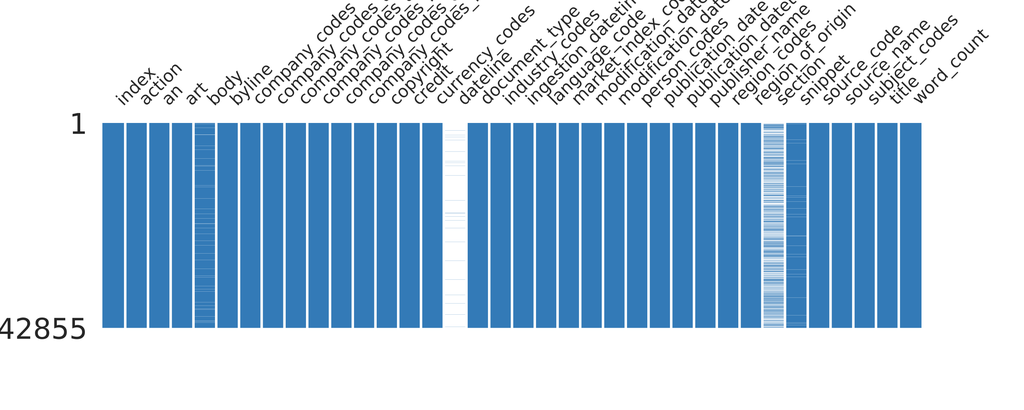

## Count

[figure not shown]

## Heatmap

[figure not shown]

## Dendrogram

[figure not shown]

# Sample

## First rows

|  | action | an | art | body | byline | company_codes | company_codes_about | company_codes_association | company_codes_lineage | company_codes_occur | company_codes_relevance | copyright | credit | currency_codes | dateline | document_type | industry_codes | ingestion_datetime | language_code | market_index_codes | modification_date | modification_datetime | person_codes | publication_date | publication_datetime | publisher_name | region_codes | region_of_origin | section | … |
| --- | --- | --- | --- | --- | --- | --- | --- | --- | --- | --- | --- | --- | --- | --- | --- | --- | --- | --- | --- | --- | --- | --- | --- | --- | --- | --- | --- | --- | --- | --- |
| 0 | add | LFSW000020140117ea1l0039v |  | Our news editors obtained a quote from the res... |  | ,unvale,unvale,unvale, | ,unvale, |  |  | ,unvale, | ,unvale, | © Copyright 2014 Life Science Weekly via NewsR... |  |  | NaN | article | ,i25,i257,i951,ibasicm, | 1389922488000 | en |  | 1541261186809 | 1389922488000 |  | 1390262400000 | 1390262400000 | NewsRx.com | ,spain,usa,valenc,eecz,eurz,medz,namz,weurz, | NAMZ USA | NaN | … |
| 1 | add | INDFED0020140110ea1a000c4 |  | CymaBay Therapeutics Inc., a biopharmaceutical... |  | ,mtblks,mtblks,mtblks,seexc, | ,mtblks, |  |  | ,mtblks, | ,seexc,mtblks, | Copyright 2014. HT Media Limited. All rights r... |  |  | NaN | article | ,itheradv,i372,i951,iphmed,i2569,ibiother, | 1389337416000 | en |  | 1541260658587 | 1389337416000 | ,118382197,118382197,118382197, | 1389312000000 | 1389312000000 | HT Media Limited | ,usa,namz, | NAMZ USA | NaN | … |
| 2 | rep | LAWRET0020160708ec7700003 |  | Here are three articles from our archives that... | Lynne Anderson \| The Conversation | ,purdp,wsguvl,purdp,purdp,rbwdjf,unvpnl,unvpnl... | ,wsguvl,purdp, |  |  | ,wsguvl,unvpnl,purdp, | ,wsguvl,unvpnl,rbwdjf,purdp, | Copyright 2016 The Eagle-Tribune / Community N... |  |  | NaN | article | ,ipresc,i257,i951,i2578, | 1467939806000 | en |  | 1541255345336 | 1481644789000 |  | 1467849600000 | 1467849600000 | Community Newspaper Holdings, Inc. | ,usma,namz,usa,use,usnew, | NAMZ USA | Cnhi Network | … |
| 3 | add | PBRELS0020140117e9cn00004 |  | PBR Pharmaceutical Business Review\n\nWebsite:... |  |  |  |  |  |  |  | © 2013 Elsevier Engineering Information |  |  | NaN | article | ,i257,i951, | 1389949456000 | en |  | 1541258417326 | 1389949456000 |  | 1387756800000 | 1387756800000 | Elsevier Science Ltd. | ,namz,usa, | EUR UK WEURZ | NaN | … |
| 4 | rep | BIWK000020140110ea1f000lq |  | The news reporters obtained a quote from the r... |  | ,ucb, |  |  |  |  | ,ucb, | (c) Copyright 2014, Biotech Week via NewsRx.com |  |  | NaN | article | ,i257,i951, | 1389315828000 | en |  | 1541257796563 | 1389612717000 |  | 1389744000000 | 1389744000000 | NewsRx.com | ,uk,usa,eecz,eurz,namz,weurz, | NAMZ USA | NaN | … |
| 5 | add | POLGOV0020140124ea1u002pn |  | News editors obtained the following quote from... |  |  |  |  |  |  |  | © Copyright 2014 Politics & Government Week vi... |  |  | NaN | article | ,i257,i951, | 1390527344000 | en |  | 1541255180406 | 1390527344000 |  | 1391040000000 | 1391040000000 | NewsRx.com | ,usa,namz, | NAMZ USA | NaN | … |
| 6 | rep | LBA0000020180409ee4900orr |  | The FDA said https://www.fda.gov/NewsEvents/Ne... |  | ,usfda,byer,byer,usfda,usfda,byer, | ,byer,usfda, |  |  | ,usfda,byer, | ,usfda,byer, | Copyright 2018 Thomson Reuters. All Rights Res... |  |  | NaN | article | ,i257,i951, | 1523293539000 | en |  | 1541261608764 | 1523295001000 |  | 1523294983000 | 1523294983000 | Thomson Reuters (Markets) LLC | ,usa,namz, | EUR UK WEURZ |  | … |
| 7 | add | ATPHAM0020160123ec1j000dy |  | "This gift allows us to create two state-of-th... |  | ,usbank,munshi,munshi,usbank,usbank,staban, | ,usbank, |  | ,staban, | ,usbank,munshi, | ,usbank,munshi, | Copyright © 2016. Contify.com | Distributed by Contify.com |  | NaN | article | ,i257,i951,i814,i81402,ibnk,ifinal, | 1453560551000 | en |  | 1541259690281 | 1453560551000 | ,68906175,68906175,68906175, | 1453161600000 | 1453161600000 | Athena Information Solutions Pvt. Ltd. | ,usa,usmi,usoh,namz,usc, | ASIA INDIA SASIAZ | NaN | … |
| 8 | rep | DJDN000020140123ea1n003ix |  | The company has continued to face challenges f... | By Tess Stynes | ,insurg,insurg,insurg, | ,insurg, |  |  | ,insurg, | ,insurg, | Copyright © 2014, Dow Jones & Company, Inc. |  |  | NaN | article | ,i372,i951, | 1390512688000 | en | ,xdjgic,xdjglc,xdjiic,xdjlc,xna100,xr3000,xsp500, | 1541256320464 | 1390512972000 |  | 1390512600000 | 1390512600000 | Dow Jones & Company, Inc. | ,usa,namz, | NAMZ USA | NaN | … |
| 9 | add | DRGW000020161209ecc90002m |  | The news reporters obtained a quote from the r... |  | ,elsv,elsv, |  |  |  | ,elsv, | ,elsv, | © Copyright 2016, Drug Week via NewsRx.com |  |  | NaN | article | ,i257,i25,i3dprn,ibioph,i2569,i951,ibasicm,itech, | 1481324976000 | en |  | 1541259554204 | 1481324976000 |  | 1481241600000 | 1481241600000 | NewsRX, LLC | ,uk,neth,usa,benluxz,eecz,eurz,namz,weurz, | NAMZ USA |  | … |

## Last rows

|  | action | an | art | body | byline | company_codes | company_codes_about | company_codes_association | company_codes_lineage | company_codes_occur | company_codes_relevance | copyright | credit | currency_codes | dateline | document_type | industry_codes | ingestion_datetime | language_code | market_index_codes | modification_date | modification_datetime | person_codes | publication_date | publication_datetime | publisher_name | region_codes | region_of_origin | section | … |
| --- | --- | --- | --- | --- | --- | --- | --- | --- | --- | --- | --- | --- | --- | --- | --- | --- | --- | --- | --- | --- | --- | --- | --- | --- | --- | --- | --- | --- | --- | --- |
| 102220 | add | DJDN000020181101eeb1001rp |  | LITTLE FALLS, N.J., Nov. 1, 2018\n\nLITTLE FAL... |  | ,ctind,bosts,byer,ctind,ctind,seexc,stjm, | ,ctind, |  |  | ,ctind, | ,stjm,seexc,ctind,byer,bosts, | Copyright © 2018, Dow Jones & Company, Inc. |  |  | NaN | article | ,i372,i951, | 1541077212000 | en | ,xdjgic,xdjiic,xnyci,xr3000,xsp400, | 1541258947641 | 1541077212000 | ,113647804,113647804,147435431,147435431, | 1541077203920 | 1541077203920 | Dow Jones & Company, Inc. | ,usnj,namz,usa,use, | NAMZ USA |  | … |
| 102221 | add | ATPHAM0020160504ec530003u |  | * Entered into long-term INTERCEPT platelet an... |  | ,cercor,usfda,aredcs,aredcs,cercor,cercor,oxfo... | ,usfda,cercor, |  |  | ,usfda,oxfofc,cercor,aredcs, | ,usfda,oxfofc,cercor,aredcs, | Copyright © 2016. Contify.com | Distributed by Contify.com |  | NaN | article | ,i257,i951,i372,iphmed, | 1462358772000 | en |  | 1541260919033 | 1462358772000 |  | 1462233600000 | 1462233600000 | Athena Information Solutions Pvt. Ltd. | ,usa,namz, | ASIA INDIA SASIAZ |  | … |
| 102222 | add | PRTRIN0020150515eb5f002mh |  | The drug belongs to a group of anti-viral medi... |  | ,stride,usfda,stride,stride,usfda, | ,usfda,stride, |  |  | ,stride, | ,usfda,stride, | Copyright 2015. The Press Trust of India Limit... |  |  | NaN | article | ,i257,i951, | 1431670977000 | en |  | 1541260135658 | 1431670977000 |  | 1431648000000 | 1431648000000 | Press Trust Of India Limited | ,usa,namz, | ASIA INDIA SASIAZ | BUSINESS | … |
| 102223 | add | JOENG00020160502ec520010q |  | Reporters obtained the following quote from th... |  | ,idtgmb,euruno,euruno,idtgmb,idtgmb, | ,idtgmb, |  |  | ,idtgmb,euruno, | ,idtgmb,euruno, | © Copyright 2016 Journal of Engineering via Ve... |  |  | NaN | article | ,i2569,i2572,i257,i951,idrugty, | 1462226978000 | en |  | 1541257229125 | 1462226978000 |  | 1462147200000 | 1462147200000 | NewsRX, LLC | ,usa,namz, | NAMZ USA | NaN | … |
| 102224 | add | RTTNEW0020181101eeb1003mn |  |  | editorial@rttnews.com (RTT Staff Writer) | ,geronc,geronc,geronc, | ,geronc, |  |  | ,geronc, | ,geronc, | Copyright © 2018 RTTNews. All rights reserved |  |  | NaN | article | ,i2569,i257,i951,ibioph, | 1541104860000 | en |  | 1541257832482 | 1541104860000 |  | 1541030400000 | 1541030400000 | Content Engine LLC | ,usa,namz, | NAMZ USA | RTTN | … |
| 102225 | add | PZON000020150505eb550001q |  | Links to a live audio webcast and replay of th... |  | ,biocst,biocst,biocst,boasl,boasl,nasdaq,seexc... | ,ncnbco,merly,biocst, |  |  | ,boasl,biocst, | ,usfda,seexc,nasdaq,boasl,biocst, | © Copyright 2015 GlobeNewswire, Inc. All Right... |  |  | NaN | article | ,i257,i951,i2569,i814,i81402,i831,i83101,ibiop... | 1430823990000 | en |  | 1541259146269 | 1430823990000 |  | 1430823960000 | 1430823960000 | GlobeNewswire, Inc. | ,usa,namz, | NAMZ USA | NaN | … |
| 102226 | add | ICROWDN020181116eebg00030 |  | With the slowdown in world economic growth, th... |  | ,alkerm,alkerm,bekdik,bekdik,btl,btl,ggag,ggag... |  |  |  | ,teviy,terc,schosa,pfiz,lilye,ggag,btl,bekdik,... | ,teviy,terc,schosa,pfiz,lilye,ggag,btl,bekdik,... | © Copyright iCrowdNewswire LLC 2018. All right... |  |  | NaN | article | ,i257,iddtech,i372,i951, | 1542330031000 | en |  | 1542424473101 | 1542330031000 |  | 1542326400000 | 1542326400000 | iCrowdNewswire, LLC | ,uk,usa,eecz,eurz,namz,weurz, | NAMZ USA |  | … |
| 102227 | add | DJDN000020150205eb25001re |  | Becton Dickinson now expects 2015 revenue grow... | By Angela Chen | ,bekdik,bekdik,bekdik, | ,bekdik, |  |  | ,bekdik, | ,bekdik, | Copyright © 2015, Dow Jones & Company, Inc. |  |  | NaN | article | ,i372,i951,iphmed, | 1423135591000 | en | ,xdjgic,xdjglc,xdjiic,xdjlc,xf500,xnyci,xr3000... | 1541255762515 | 1423135591000 |  | 1423135519004 | 1423135519004 | Dow Jones & Company, Inc. | ,usnj,namz,usa,use, | NAMZ USA | NaN | … |
| 102228 | add | PHBW000020150227eb32000fy |  | There were 4 documents filed with this form. T... |  | ,tphari,fffaim,seexc,tphari,tphari, | ,tphari, |  |  | ,tphari, | ,tphari,seexc,fffaim, | © Copyright 2015 Pharma Business Week via News... |  |  | NaN | article | ,i257,i951,i8395414,ibcs, | 1425000671000 | en |  | 1541258926274 | 1425000671000 |  | 1425254400000 | 1425254400000 | NewsRX, LLC | ,usa,namz, | NAMZ USA | NaN | … |
| 102229 | add | BTBW000020150227eb320006m |  | There was one document filed with this form. T... |  | ,regph,fffaim,regph,regph,seexc,seexc, | ,regph, |  |  | ,seexc,regph, | ,seexc,regph,fffaim, | © Copyright 2015 Biotech Business Week via New... |  |  | NaN | article | ,i257,i951, | 1424999206000 | en |  | 1541259273310 | 1424999206000 |  | 1425254400000 | 1425254400000 | NewsRX, LLC | ,usa,namz, | NAMZ USA | NaN | … |